# Untitled

Brett Skinner

2023-12-26

# Load and separate different groups

## Separate LGBTQ groups

```r
library("tidyverse")
HateCrimes <- read_csv("Hate_Crimes_filtered_cols.csv")
HateCrimes$offender_race[is.na(HateCrimes$offender_race)] <- "Unknown"
HateCrimes$Anti_Trans <- NA
HateCrimes$Anti_Trans[str_detect(HateCrimes$bias_desc, "Anti-Transgender")] <-"Y"
HateCrimes$Anti_Trans[!str_detect(HateCrimes$bias_desc, "Anti-Transgender")] <-"N"

HateCrimes$Anti_Gay <- NA
HateCrimes$Anti_Gay[str_detect(HateCrimes$bias_desc, 'Anti-Gay \\(Male\\)')] <-"Y"
HateCrimes$Anti_Gay[!str_detect(HateCrimes$bias_desc, "Anti-Gay \\(Male\\)")] <-"N"

HateCrimes$Anti_Lesbian <- NA
HateCrimes$Anti_Lesbian[str_detect(HateCrimes$bias_desc, "Anti-Lesbian \\(Female\\)")] <-"Y"
HateCrimes$Anti_Lesbian[!str_detect(HateCrimes$bias_desc, "Anti-Lesbian \\(Female\\)")] <-"N"

HateCrimes$Anti_Bi <- NA
HateCrimes$Anti_Bi[str_detect(HateCrimes$bias_desc, "Anti-Bisexual")] <-"Y"
HateCrimes$Anti_Bi[!str_detect(HateCrimes$bias_desc, "Anti-Bisexual")] <-"N"

HateCrimes$Anti_Fluid <- NA
HateCrimes$Anti_Fluid[str_detect(HateCrimes$bias_desc, "Anti-Gender Non-Conforming")] <-"Y"
HateCrimes$Anti_Fluid[!str_detect(HateCrimes$bias_desc, "Anti-Gender Non-Conforming")] <-"N"

HateCrimes$Anti_LGBTQ <- NA
HateCrimes$Anti_LGBTQ[str_detect(HateCrimes$bias_desc, "Anti-Gay \\(Male\\)") |
                       str_detect(HateCrimes$bias_desc, "Anti-Lesbian \\(Female\\)") |
                       str_detect(HateCrimes$bias_desc, "Anti-Lesbian, Gay, Bisexual, or Transgender (Mixed Group)") |
                       str_detect(HateCrimes$bias_desc, "Anti-Bisexual") |
                       str_detect(HateCrimes$bias_desc, "Anti-Gender Non-Conforming") |
                       str_detect(HateCrimes$bias_desc, "Anti-Transgender")] <- "Y"

HateCrimes$Anti_LGBTQ[!(str_detect(HateCrimes$bias_desc, "Anti-Gay \\(Male\\)") |
                        str_detect(HateCrimes$bias_desc, "Anti-Lesbian \\(Female\\)") |
                        str_detect(HateCrimes$bias_desc, "Anti-Lesbian, Gay, Bisexual, or Transgender (Mixed Group)") |
                        str_detect(HateCrimes$bias_desc, "Anti-Bisexual") |
                        str_detect(HateCrimes$bias_desc, "Anti-Gender Non-Conforming") |
                        str_detect(HateCrimes$bias_desc, "Anti-Transgender"))] <- "N"

HateCrimes$Anti_Hetero <- NA
HateCrimes$Anti_Hetero[str_detect(HateCrimes$bias_desc, "Anti-Heterosexual")] <- "Y"
HateCrimes$Anti_Hetero[!str_detect(HateCrimes$bias_desc, "Anti-Heterosexual")] <- "N"
```

## Separate by Race

```r
HateCrimes$Anti_Black <- NA
HateCrimes$Anti_Black[str_detect(HateCrimes$bias_desc, "Anti-Black or African American")] <- "Y"
HateCrimes$Anti_Black[!str_detect(HateCrimes$bias_desc, "Anti-Black or African American")] <- "N"

HateCrimes$Anti_White <- NA
HateCrimes$Anti_White[str_detect(HateCrimes$bias_desc, "Anti-White")] <- "Y"
HateCrimes$Anti_White[!str_detect(HateCrimes$bias_desc, "Anti-White")] <- "N"

HateCrimes$Anti_Asian <- NA
HateCrimes$Anti_Asian[str_detect(HateCrimes$bias_desc, "Anti-Asian")] <- "Y"
HateCrimes$Anti_Asian[!str_detect(HateCrimes$bias_desc, "Anti-Asian")] <- "N"

HateCrimes$Anti_Pac_Isl <- NA
HateCrimes$Anti_Pac_Isl[str_detect(HateCrimes$bias_desc, "Anti-Native Hawaiian or Other Pacific Islander")] <- "Y"
HateCrimes$Anti_Pac_Isl[!str_detect(HateCrimes$bias_desc, "Anti-Native Hawaiian or Other Pacific Islander")] <- "N"

HateCrimes$Anti_Native_Am <- NA
HateCrimes$Anti_Native_Am[str_detect(HateCrimes$bias_desc, "Anti-American Indian or Alaska Native")] <- "Y"
HateCrimes$Anti_Native_Am[!str_detect(HateCrimes$bias_desc, "Anti-American Indian or Alaska Native")] <- "N"

HateCrimes$Anti_Multiple_race <- NA
HateCrimes$Anti_Multiple_race[str_detect(HateCrimes$bias_desc, "Anti-Multiple Races")] <- "Y"
HateCrimes$Anti_Multiple_race[!str_detect(HateCrimes$bias_desc, "Anti-Multiple Races")] <- "N"

HateCrimes$Anti_Hispanic <- NA
HateCrimes$Anti_Hispanic[str_detect(HateCrimes$bias_desc, "Anti-Hispanic or Latino")] <- "Y"
HateCrimes$Anti_Hispanic[!str_detect(HateCrimes$bias_desc, "Anti-Hispanic or Latino")] <- "N"

HateCrimes$Anti_Arab <- NA
HateCrimes$Anti_Arab[str_detect(HateCrimes$bias_desc, "Anti-Arab")] <- "Y"
HateCrimes$Anti_Arab[!str_detect(HateCrimes$bias_desc, "Anti-Arab")] <- "N"

HateCrimes$Anti_Jewish <- NA
HateCrimes$Anti_Jewish[str_detect(HateCrimes$bias_desc, "Anti-Jewish")] <- "Y"
HateCrimes$Anti_Jewish[!str_detect(HateCrimes$bias_desc, "Anti-Jewish")] <- "N"

HateCrimes$Anti_Other_Race <- NA
HateCrimes$Anti_Other_Race[str_detect(HateCrimes$bias_desc, "Anti-Other Race/Ethnicity/Ancestry")] <- "Y"
HateCrimes$Anti_Other_Race[!str_detect(HateCrimes$bias_desc, "Anti-Other Race/Ethnicity/Ancestry")] <- "N"

HateCrimes$Anti_Racial <- NA
HateCrimes$Anti_Racial[HateCrimes$Anti_Black == "Y" |
                    HateCrimes$Anti_White == "Y" |
                    HateCrimes$Anti_Asian == "Y" |
                    HateCrimes$Anti_Pac_Isl == "Y" |
                    HateCrimes$Anti_Native_Am == "Y" |
                    HateCrimes$Anti_Multiple_race == "Y" |
                    HateCrimes$Anti_Hispanic == "Y" |
                    HateCrimes$Anti_Arab == "Y" |
                    HateCrimes$Anti_Jewish == "Y" |
                    HateCrimes$Anti_Other_Race == "Y"] <- "Y"
HateCrimes$Anti_Racial[!(HateCrimes$Anti_Black == "Y" |
                    HateCrimes$Anti_White == "Y" |
                    HateCrimes$Anti_Asian == "Y" |
                    HateCrimes$Anti_Pac_Isl == "Y" |
                    HateCrimes$Anti_Native_Am == "Y" |
                    HateCrimes$Anti_Multiple_race == "Y" |
                    HateCrimes$Anti_Hispanic == "Y" |
                    HateCrimes$Anti_Arab == "Y" |
                    HateCrimes$Anti_Jewish == "Y" |
                    HateCrimes$Anti_Other_Race == "Y")] <- "N"
```

# Separate by Religion

```r
HateCrimes$Anti_Catholic <- NA
HateCrimes$Anti_Catholic[str_detect(HateCrimes$bias_desc, "Anti-Catholic")] <- "Y"
HateCrimes$Anti_Catholic[!str_detect(HateCrimes$bias_desc, "Anti-Catholic")] <- "N"

HateCrimes$Anti_Protestant <- NA
HateCrimes$Anti_Protestant[str_detect(HateCrimes$bias_desc, "Anti-Protestant")] <- "Y"
HateCrimes$Anti_Protestant[!str_detect(HateCrimes$bias_desc, "Anti-Protestant")] <- "N"

HateCrimes$Anti_Jehovah <- NA
HateCrimes$Anti_Jehovah[str_detect(HateCrimes$bias_desc, "Anti-Jehovah's Witness")] <- "Y"
HateCrimes$Anti_Jehovah[!str_detect(HateCrimes$bias_desc, "Anti-Jehovah's Witness")] <- "N"

HateCrimes$Anti_Mormon <- NA
HateCrimes$Anti_Mormon[str_detect(HateCrimes$bias_desc, "Anti-Mormon")] <- "Y"
HateCrimes$Anti_Mormon[!str_detect(HateCrimes$bias_desc, "Anti-Mormon")] <- "N"

HateCrimes$Anti_Buddhist <- NA
HateCrimes$Anti_Buddhist[str_detect(HateCrimes$bias_desc, "Anti-Buddhist")] <- "Y"
HateCrimes$Anti_Buddhist[!str_detect(HateCrimes$bias_desc, "Anti-Buddhist")] <- "N"

HateCrimes$Anti_Sikh <- NA
HateCrimes$Anti_Sikh[str_detect(HateCrimes$bias_desc, "Anti-Sikh")] <- "Y"
HateCrimes$Anti_Sikh[!str_detect(HateCrimes$bias_desc, "Anti-Sikh")] <- "N"

HateCrimes$Anti_Other_Christian <- NA
HateCrimes$Anti_Other_Christian[str_detect(HateCrimes$bias_desc, "Anti-Other Christian")] <- "Y"
HateCrimes$Anti_Other_Christian[!str_detect(HateCrimes$bias_desc, "Anti-Other Christian")] <- "N"

HateCrimes$Anti_Hindu <- NA
HateCrimes$Anti_Hindu[str_detect(HateCrimes$bias_desc, "Anti-Hindu")] <- "Y"
HateCrimes$Anti_Hindu[!str_detect(HateCrimes$bias_desc, "Anti-Hindu")] <- "N"

HateCrimes$Anti_Atheist <- NA
HateCrimes$Anti_Atheist[str_detect(HateCrimes$bias_desc, "Anti-Atheism/Agnosticism")] <- "Y"
HateCrimes$Anti_Atheist[!str_detect(HateCrimes$bias_desc, "Anti-Atheism/Agnosticism")] <- "N"

HateCrimes$Anti_East_Orthodox <- NA
HateCrimes$Anti_East_Orthodox[str_detect(HateCrimes$bias_desc, "Anti-Eastern Orthodox \\(Russian, Greek, Other\\)")] <- "Y"
HateCrimes$Anti_East_Orthodox[!str_detect(HateCrimes$bias_desc, "Anti-Eastern Orthodox \\(Russian, Greek, Other\\)")] <- "N"

HateCrimes$Anti_Islamic <- NA
HateCrimes$Anti_Islamic[str_detect(HateCrimes$bias_desc, "Anti-Islamic \\(Muslim\\)")] <- "Y"
HateCrimes$Anti_Islamic[!str_detect(HateCrimes$bias_desc, "Anti-Islamic \\(Muslim\\)")] <- "N"

HateCrimes$Anti_Other_Religion <- NA
HateCrimes$Anti_Other_Religion[str_detect(HateCrimes$bias_desc, "Anti-Other Religion")] <- "Y"
HateCrimes$Anti_Other_Religion[!str_detect(HateCrimes$bias_desc, "Anti-Other Religion")] <- "N"

HateCrimes$Anti_Multiple_Religion <- NA
HateCrimes$Anti_Multiple_Religion[str_detect(HateCrimes$bias_desc, "Anti-Multiple Religions, Group")] <- "Y"
HateCrimes$Anti_Multiple_Religion[!str_detect(HateCrimes$bias_desc, "Anti-Multiple Religions, Group")] <- "N"

HateCrimes$Anti_Religious <- NA
HateCrimes$Anti_Religious[HateCrimes$Anti_Jewish == "Y" |
                            HateCrimes$Anti_Catholic == "Y" |
                            HateCrimes$Anti_Protestant == "Y" |
                            HateCrimes$Anti_Jehovah == "Y" |
                            HateCrimes$Anti_Mormon == "Y" |
                            HateCrimes$Anti_Buddhist == "Y" |
                            HateCrimes$Anti_Sikh == "Y" |
                            HateCrimes$Anti_Other_Christian == "Y" |
                            HateCrimes$Anti_Hindu == "Y" |
                            HateCrimes$Anti_East_Orthodox == "Y" |
                            HateCrimes$Anti_Islamic == "Y" |
                            HateCrimes$Anti_Other_Religion == "Y" |
                            HateCrimes$Anti_Multiple_Religion == "Y"] <-"Y"
HateCrimes$Anti_Religious[!(HateCrimes$Anti_Jewish == "Y" |
                            HateCrimes$Anti_Catholic == "Y" |
                            HateCrimes$Anti_Protestant == "Y" |
                            HateCrimes$Anti_Jehovah == "Y" |
                            HateCrimes$Anti_Mormon == "Y" |
                            HateCrimes$Anti_Buddhist == "Y" |
                            HateCrimes$Anti_Sikh == "Y" |
                            HateCrimes$Anti_Other_Christian == "Y" |
                            HateCrimes$Anti_Hindu == "Y" |
                            HateCrimes$Anti_East_Orthodox == "Y" |
                            HateCrimes$Anti_Islamic == "Y" |
                            HateCrimes$Anti_Other_Religion == "Y" |
                            HateCrimes$Anti_Multiple_Religion == "Y")] <-"N"
```

- Note that there isn’t a distinction between ethnicly Jewish and Religiously Jewish

## Separate by gender

```r
HateCrimes$Anti_Female <- NA
HateCrimes$Anti_Female[str_detect(HateCrimes$bias_desc, "Anti-Female")] <- "Y"
HateCrimes$Anti_Female[!str_detect(HateCrimes$bias_desc, "Anti-Female")] <- "N"

HateCrimes$Anti_Male <- NA
HateCrimes$Anti_Male[str_detect(HateCrimes$bias_desc, "Anti-Male")] <- "Y"
HateCrimes$Anti_Male[!str_detect(HateCrimes$bias_desc, "Anti-Male")] <- "N"
```

## Separate by disability

```r
HateCrimes$Anti_Phy_Disability <- NA
HateCrimes$Anti_Phy_Disability[str_detect(HateCrimes$bias_desc, "Anti-Physical Disability")] <- "Y"
HateCrimes$Anti_Phy_Disability[!str_detect(HateCrimes$bias_desc, "Anti-Physical Disability")] <- "N"

HateCrimes$Anti_Men_Disability <- NA
HateCrimes$Anti_Men_Disability[str_detect(HateCrimes$bias_desc, "Anti-Mental Disability")] <- "Y"
HateCrimes$Anti_Men_Disability[!str_detect(HateCrimes$bias_desc, "Anti-Mental Disability")] <- "N"

HateCrimes$Anti_Disability <- NA
HateCrimes$Anti_Disability[HateCrimes$Anti_Men_Disability == "Y" |
                             HateCrimes$Anti_Phy_Disability == "Y"] <- "Y"
HateCrimes$Anti_Disability[HateCrimes$Anti_Men_Disability == "N" &
                             HateCrimes$Anti_Phy_Disability == "N"] <- "N"
```

### Separating the date into day month and year.

```r
HateCrimes[c("day", "month", "year")] <- str_split_fixed(HateCrimes$incident_date, "-", 3)
HateCrimes$year <- format(as.Date(HateCrimes$year, "%y"), "%Y")
HateCrimes$day <- format(as.Date(HateCrimes$day, "%d"), "%d")
```

# Compare Religious, Racial and LGBTQ hate crimes.

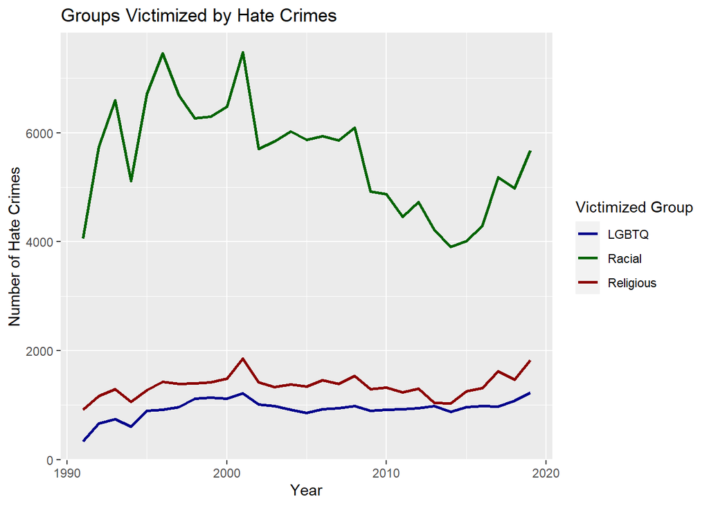

```r
Total_Main <- list()
for(i in 1:29){
  Total_Main[[i]] <- c(nrow(filter(HateCrimes, Anti_LGBTQ == "Y" & year == 1990 + i)),
                       nrow(filter(HateCrimes, Anti_Racial == "Y" & year == 1990 + i)),
                       nrow(filter(HateCrimes, Anti_Religious == "Y" & year == 1990 + i)))
}
Total_Main <- t(data.frame(Total_Main))
rownames(Total_Main) <- c(1:29)
colnames(Total_Main) <- c("LGBTQ", "Racial", "Religious")
Total_Main <- data.frame(Total_Main)
Total_Main$year <- c(1991:2019)
# stacking the dataframe getting ready for plotting.
Total_Main_stacked <- cbind(Total_Main[4], stack(Total_Main[1:3]))
colnames(Total_Main_stacked) <- c("year", "nHate_Crimes", "bias")

ggplot(Total_Main_stacked, aes(x = year, y = nHate_Crimes)) +
  geom_line(aes(color = bias), size = 1) +
  scale_color_manual(name = "Victimized Group",
                     values = c("LGBTQ" = "darkblue", "Racial" = "darkgreen", "Religious"="darkred")) +
  xlab("Year") +
  ylab("Number of Hate Crimes") +
  ggtitle("Groups Victimized by Hate Crimes")
```

- 1989 - The Hate Crimes Statistics Act is adopted. Justice Department is tasked with collecting and publishing data about crimes motivated by hatred based on Race, Religion, Ethnicity, and Sexual Orientation.
- 1993 - Legislation is passed allowing judges to impose harsher punishments for hate crimes. (numbers dip for a year in 1994)
- 1997 - Hate Crime Prevention Act is introduced; extending more “protection of the current federal hate crimes law to include those who are victimized because of their sexual orientation, gender or disability.” (https://www.hrc.org/resources/hate-crimes-timeline#1990)
- 1999 - Hate Crimes Prevention Act is passed.
- In terms of total hate crimes, racial hate crimes occur way more often than the other groups, but LGBTQ populations make up less of the population than the other two groups.
- we need to look at per capita hate crimes.

```r
LGBTQ_Population <- read_csv("LGBTQ_Population.csv")
```

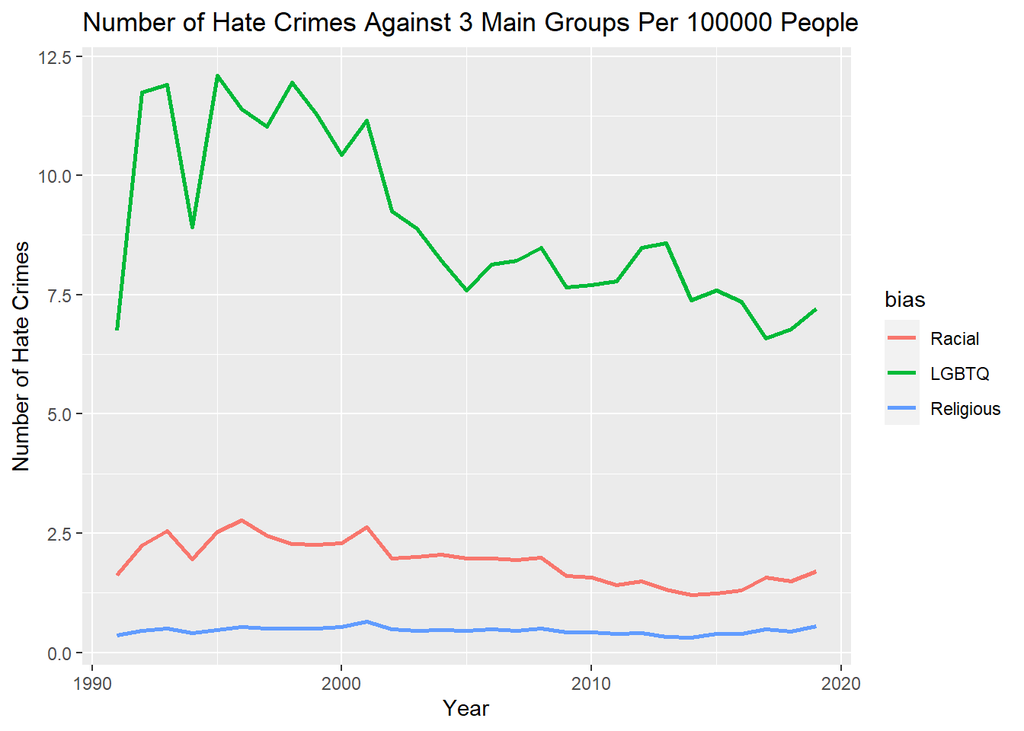

```r
LGBTQ_Capita <- data.frame(year = c(1991:2019))
LGBTQ_Capita$Racial <- round(100000*Total_Main$Racial/LGBTQ_Population$US_Population, digits = 2)
LGBTQ_Capita$LGBTQ <- round(100000*Total_Main$LGBTQ/LGBTQ_Population$LGBTQ_Population, digits = 2)
LGBTQ_Capita$Religious <- round(100000*Total_Main$Religious/LGBTQ_Population$US_Population, digits = 2)
LGBTQ_Capita_stacked <- cbind(LGBTQ_Capita[1], stack(LGBTQ_Capita[2:4]))
colnames(LGBTQ_Capita_stacked) <- c("Year", "nHate_Crimes", "bias")

ggplot(data = LGBTQ_Capita_stacked, mapping = aes(x = Year, y = nHate_Crimes)) +
  geom_line(mapping = aes(color = bias), size = 1) +
  xlab("Year") +
  ylab("Number of Hate Crimes") +
  ggtitle("Number of Hate Crimes Against 3 Main Groups Per 100000 People")
```

# LGBTQ

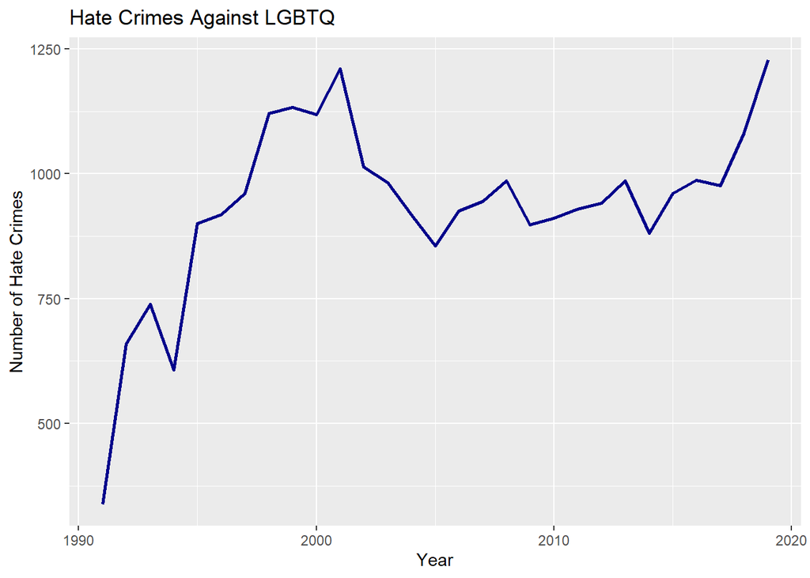

```r
ggplot(select(Total_Main,c("year", "LGBTQ")), aes(x = year, y = LGBTQ)) +
  geom_line(size = 1, color = "darkblue") +
  xlab("Year") +
  ylab("Number of Hate Crimes") +
  ggtitle("Hate Crimes Against LGBTQ")
```

## Separating the different groups under the LGBTQ umbrella

```r
LGBTQ_Total <- list()
for(i in 1:29){
  LGBTQ_Total[[i]] <- c(nrow(filter(HateCrimes, Anti_Trans == "Y" & year == 1990 + i)),
                       nrow(filter(HateCrimes, Anti_Gay == "Y" & year == 1990 + i)),
                       nrow(filter(HateCrimes, Anti_Lesbian == "Y" & year == 1990 + i)),
                       nrow(filter(HateCrimes, Anti_Bi == "Y" & year == 1990 + i)),
                       nrow(filter(HateCrimes, Anti_Fluid == "Y" & year == 1990 + i)))
}

LGBTQ_Total <- t(data.frame(LGBTQ_Total))
rownames(LGBTQ_Total) <- c(1:29)
colnames(LGBTQ_Total) <- c("Transgender", "Gay", "Lesbian", "Bisexual", "Gender_Non_Conforming")
LGBTQ_Total <- data.frame(LGBTQ_Total)
LGBTQ_Total$year <- c(1991:2019)
LGBTQ_Total_stacked <- cbind(LGBTQ_Total[6], stack(LGBTQ_Total[1:5]))
```

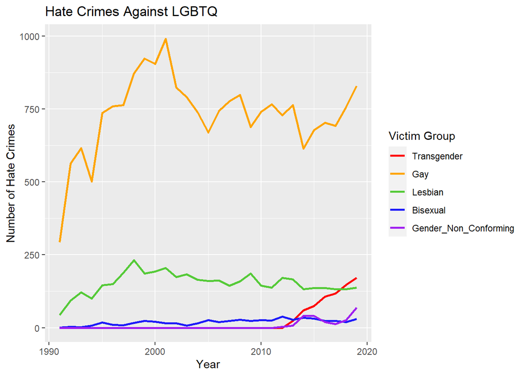

```r
colnames(LGBTQ_Total_stacked) <- c("year", "nHate_Crimes", "bias")

ggplot(LGBTQ_Total_stacked, mapping = aes(x  = year, y = nHate_Crimes)) +
  geom_line(aes(color = bias), size = 1) +
  scale_color_manual(name = "Victim Group",
                     values = c("Gender_Non_Conforming" = "purple",
                                "Transgender" = "red",
                                "Bisexual" = "#1D1af9",
                                "Gay" = "orange",
                                "Lesbian" = "#55ca38")) +
  ggtitle("Hate Crimes Against LGBTQ") +
  xlab("Year") +
  ylab("Number of Hate Crimes")
```

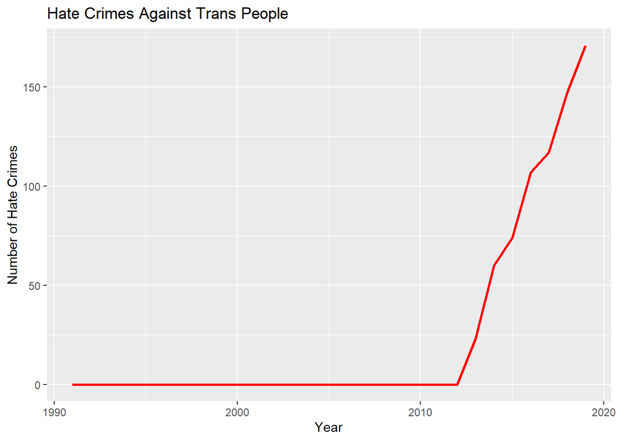

```r
ggplot(data = subset(LGBTQ_Total, select = c(Transgender, year)), mapping = aes(x = year, y = Transgender)) +
  geom_line(color = "red", size = 1) +
  ggtitle("Hate Crimes Against Trans People") +
  xlab("Year") +
  ylab("Number of Hate Crimes")
```

- Immediately we see that hate crimes against gays are the majority of the hate crimes against LGBTQ.
- In recent years it looks like hate crimes against Transgender and Gender non-conforming has spiked. This is in part due to the lack of ability to classify hate crimes against Trans individuals before 2009. They have also been thrust into the spotlight post Obergefell (2015).
- We notice that hate crimes agains gays were lower in 2014 and we see an increase in and after 2015.

# Hate Crimes Against Relgious Groups

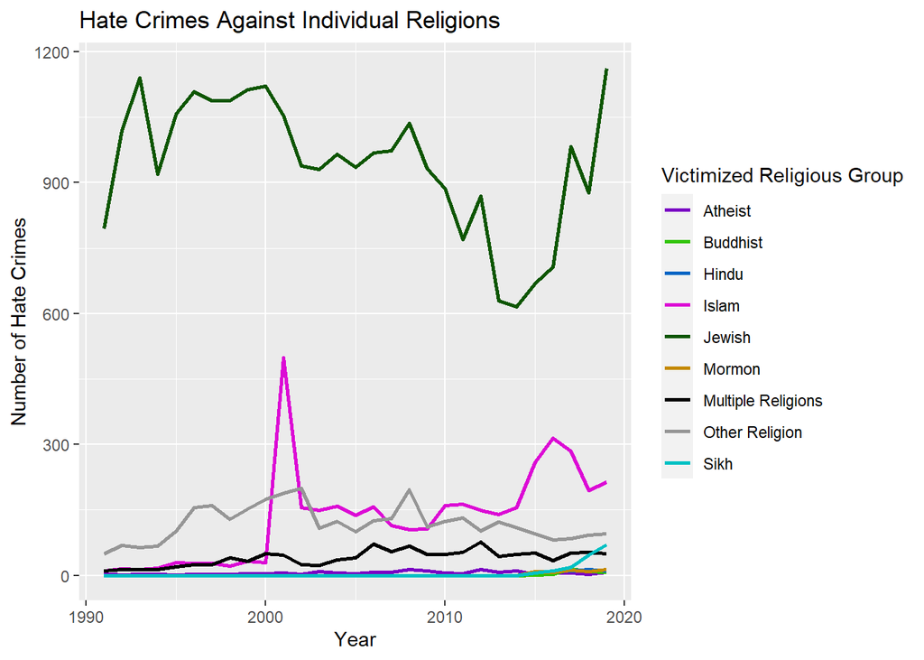

```r
Religious_Total <- list()
for(i in 1:29){
  Religious_Total[[i]] <- c(nrow(filter(HateCrimes, Anti_Catholic == "Y" & year == 1990 + i)),
                        nrow(filter(HateCrimes, Anti_Protestant == "Y" & year == 1990 + i)),
                        nrow(filter(HateCrimes, Anti_Jewish == "Y" & year == 1990 + i)),
                        nrow(filter(HateCrimes, Anti_Jehovah == "Y" & year == 1990 + i)),
                        nrow(filter(HateCrimes, Anti_Mormon == "Y" & year == 1990 + i)),
                        nrow(filter(HateCrimes, Anti_Buddhist == "Y" & year == 1990 + i)),
                        nrow(filter(HateCrimes, Anti_Sikh == "Y" & year == 1990 + i)),
                        nrow(filter(HateCrimes, Anti_East_Orthodox == "Y" & year == 1990 + i)),
                        nrow(filter(HateCrimes, Anti_Hindu == "Y" & year == 1990 + i)),
                        nrow(filter(HateCrimes, Anti_Other_Christian == "Y" & year == 1990 + i)),
                        nrow(filter(HateCrimes, Anti_Atheist == "Y" & year == 1990 + i)),
                        nrow(filter(HateCrimes, Anti_Islamic == "Y" & year == 1990 + i)),
                        nrow(filter(HateCrimes, Anti_Other_Religion == "Y" & year == 1990 + i)),
                        nrow(filter(HateCrimes, Anti_Multiple_Religion == "Y" & year == 1990 + i)))
}

Religious_Total <- t(data.frame(Religious_Total))
rownames(Religious_Total) <- c(1:29)
colnames(Religious_Total) <- c("Catholic", "Protestant", "Jewish", "Jahovah_Witness", "Mormon", "Buddhist",
                               "Sikh","East_Orthodox","Hindu","Other_Christian","Atheist","Islam",
                               "Other_Religion", "Multiple_Religions")
Religious_Total <- data.frame(Religious_Total)
Religious_Total$year <- c(1991:2019)
Religious_Total_stacked <- cbind(Religious_Total[15], stack(Religious_Total[1:14]))
colnames(Religious_Total_stacked) <- c("year", "nHate_Crimes", "bias")
Religious_Total_stacked$bias <- as.character(Religious_Total_stacked$bias) #makes column character column
Religious_Total_stacked$bias[Religious_Total_stacked$bias == "Jahovah_Witness"] <- "Jehovahs Witness"
Religious_Total_stacked$bias[Religious_Total_stacked$bias == "East_Orthodox"] <- "Eastern Orthodox"
Religious_Total_stacked$bias[Religious_Total_stacked$bias == "Other_Christian"] <- "Other Christian"
Religious_Total_stacked$bias[Religious_Total_stacked$bias == "Other_Religion"] <- "Other Religion"
Religious_Total_stacked$bias[Religious_Total_stacked$bias == "Multiple_Religions"] <- "Multiple Religions"
Religious_Total_stacked$bias <- as.factor(Religious_Total_stacked$bias) #changes column back to factor

ggplot(subset(Religious_Total_stacked, Religious_Total_stacked$bias %in% c("Jehovas Witness",
              "Mormon",
              "Buddhist",
              "Sikh",
              "Hindu",
              "Atheist",
              "Islam",
              "Other Religion",
              "Multiple Religions",
              "Jewish")), mapping = aes(x  = year, y = nHate_Crimes)) +
  geom_line(aes(color = bias), size = 1) +
  scale_color_manual(name = "Victimized Religious Group",
                     values = c(#"Catholic" = "#751AF9",
                                #"Protestant" = "#f91a1a",
                                "Jehovas Witness" = "#c40000",
                                "Mormon" = "#c48900",
                                "Buddhist" = "#30c400",
                                "Jewish" = "#0d5600",
                                "Sikh" = "#00c1c4",
                                #"Eastern Orthodox" = "#881111",
                                "Hindu" = "#0065c4",
                                #"Other Christian" = "#f9af1a",
                                "Atheist" = "#7a00c4",
                                "Islam" = "#dc0ad5",
                                "Other Religion" = "#969696",
                                "Multiple Religions" = "#000000")) +
  ggtitle("Hate Crimes Against Individual Religions") +
  xlab("Year") +
  ylab("Number of Hate Crimes")
```

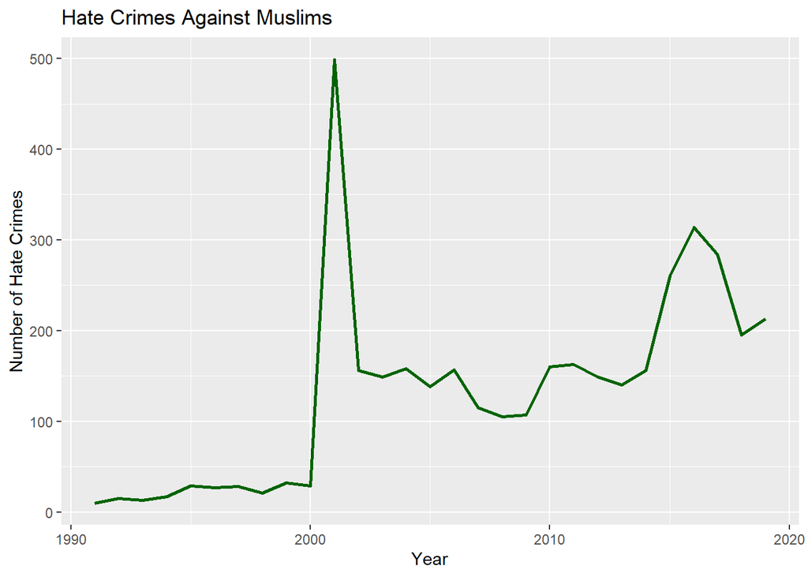

```r
ggplot(subset(Religious_Total_stacked, Religious_Total_stacked$bias=="Islam"), mapping = aes(x = year, y = nHate_Crimes)) +
  geom_line(color = "darkgreen", size = 1) +
  ggtitle("Hate Crimes Against Muslims") +
  xlab("Year") +
  ylab("Number of Hate Crimes")
```

- Note: Ethnic Jewish and Religious Jewish are combined.
- Hate Crimes against Jews is still a very pervasive problem.
- Obviously there is a spike of hate crimes against Muslims in 2001. 9/11 happened, so this is expected.
- After 9/11 the number of hate crimes never went down to pre 9/11 levels with another spike in 2015-2017 around the time where there was discussion of a Muslim ban.

## Isolating Abrahamic Religions

```r
Abraham_Total <- subset(Religious_Total, select = c("Islam", "Jewish", "Catholic", "Protestant", "Other_Christian", "East_Orthodox", "year"))
Abraham_Total$Christian <- Abraham_Total$Catholic + Abraham_Total$Protestant + Abraham_Total$Other_Christian + Abraham_Total$East_Orthodox
Abraham_Total <- subset(Abraham_Total, select = c("Islam", "Jewish", "Christian", "year"))
Abraham_Total_stacked <- cbind(Abraham_Total[4], stack(Abraham_Total[1:3]))
```

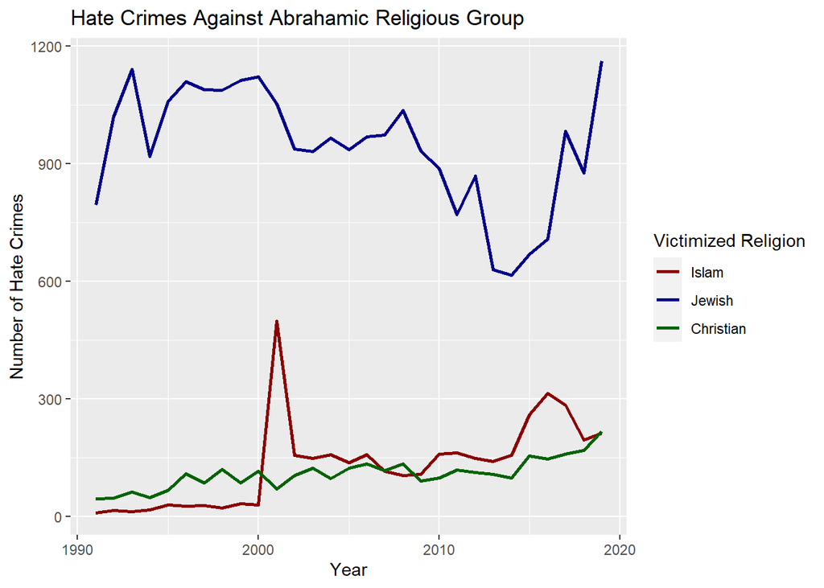

```r
colnames(Abraham_Total_stacked) <- c("year", "nHate_Crimes", "bias")

ggplot(data = Abraham_Total_stacked, mapping = aes(x = year, y = nHate_Crimes)) +
  geom_line(aes(color = bias), size = 1) +
  scale_color_manual(name = "Victimized Religion", values = c("Christian" = "darkgreen",
                                                              "Jewish" = "darkblue",
                                                              "Islam" = "darkred"))+
  xlab("Year") +
  ylab("Number of Hate Crimes") +
  ggtitle("Hate Crimes Against Abrahamic Religious Group")
```

- We can see the total number of hate crimes against Christians matches those against Muslims by 2019.
- There are many more Christians in the country than Muslims so we look at per capita next.

```r
Religious_Populations <- read_csv("Religions_US_Population.csv")
```

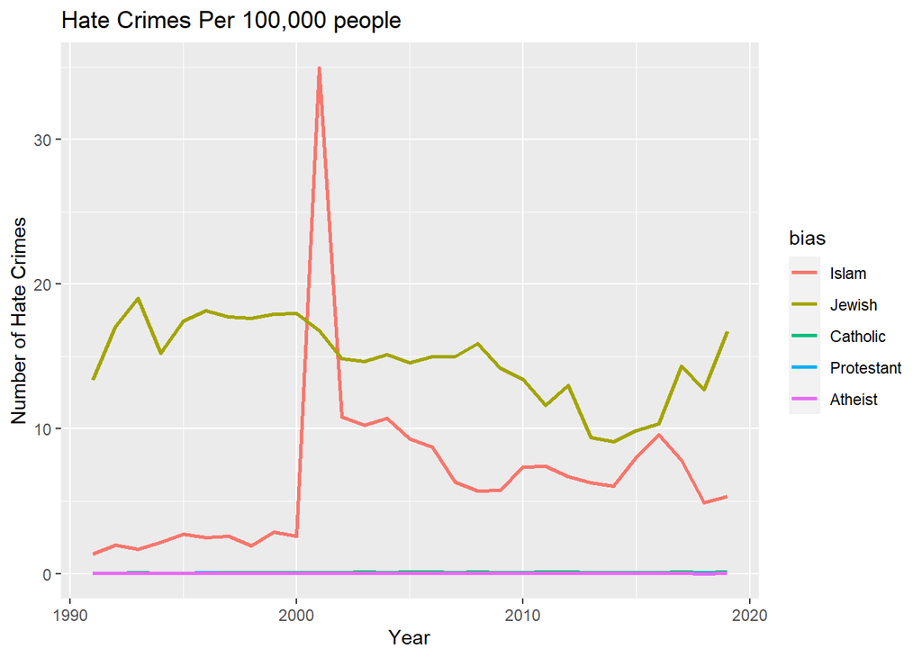

```r
Per_Capita_Religion = data.frame(year = c(1991:2019))
Per_Capita_Religion$Islam = round(100000*Abraham_Total$Islam/Religious_Populations$Islam, digits = 2)
Per_Capita_Religion$Jewish = round(100000*Abraham_Total$Jewish/Religious_Populations$Jewish, digits = 2)
Per_Capita_Religion$Catholic = round(100000*Religious_Total$Catholic/Religious_Populations$Catholic, digits = 2)
Per_Capita_Religion$Protestant = round(100000*Religious_Total$Protestant/Religious_Populations$Protestant, digits = 2)
Per_Capita_Religion$Atheist = round(100000*Religious_Total$Atheist/Religious_Populations$Atheist, digits = 2)

Per_Capita_Religion_stacked <- cbind(Per_Capita_Religion[1], stack(Per_Capita_Religion[2:6]))
colnames(Per_Capita_Religion_stacked) = c("year", "nHate_Crimes", "bias")


ggplot(data = Per_Capita_Religion_stacked, mapping = aes(x = year, y = nHate_Crimes)) +
  geom_line(mapping = aes(color = bias), size = 1) +
  xlab("Year") +
  ylab("Number of Hate Crimes") +
  ggtitle("Hate Crimes Per 100,000 people")
```

- Here we can see that hate crimes against Jews still excede that of Muslims (with exception of 2001).
- Sources: Source: https://www.pewresearch.org/religion/wp-content/uploads/sites/7/2019/11/Detailed-tables-for-upload-11.11.19.pdf
- Source: https://commons.trincoll.edu/aris/files/2011/08/ARIS_Report_2008.pdf
- Source: https://news.gallup.com/poll/1690/Religion.aspx#1
- Source: https://www.macrotrends.net/countries/USA/united-states/population
- All estimates, Jewish and Muslim are a little bit of modeling and estimating.

# Hate Crimes Against Racial Groups

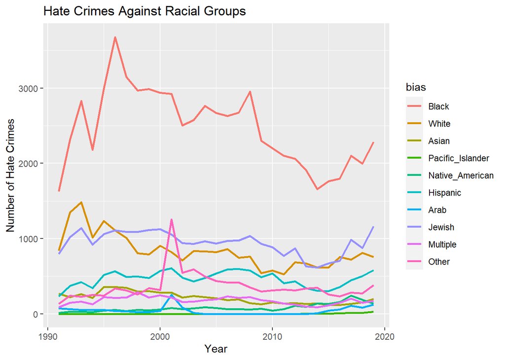

```r
Race_Total <- list()
for(i in 1:29){
  Race_Total[[i]] <- c(nrow(filter(HateCrimes, Anti_Black == "Y" & year == 1990 + i)),
                       nrow(filter(HateCrimes, Anti_White == "Y" & year == 1990 + i)),
                       nrow(filter(HateCrimes, Anti_Asian == "Y" & year == 1990 + i)),
                       nrow(filter(HateCrimes, Anti_Pac_Isl == "Y" & year == 1990 + i)),
                       nrow(filter(HateCrimes, Anti_Native_Am == "Y" & year == 1990 + i)),
                       nrow(filter(HateCrimes, Anti_Hispanic == "Y" & year == 1990 + i)),
                       nrow(filter(HateCrimes, Anti_Arab == "Y" & year == 1990 + i)),
                       nrow(filter(HateCrimes, Anti_Jewish == "Y" & year == 1990 + i)),
                       nrow(filter(HateCrimes, Anti_Multiple_race == "Y" & year == 1990 + i)),
                       nrow(filter(HateCrimes, Anti_Other_Race == "Y" & year == 1990 + i)))
}
Race_Total <- t(data.frame(Race_Total))
rownames(Race_Total) <- c(1:29)
colnames(Race_Total) <- c("Black", "White", "Asian", "Pacific_Islander",
                          "Native_American", "Hispanic", "Arab", "Jewish", "Multiple", "Other")
Race_Total <- data.frame(Race_Total)
Race_Total$year <- c(1991:2019)
# stacking the dataframe getting ready for plotting.
Race_Total_stacked <- cbind(Race_Total[11], stack(Race_Total[1:10]))
colnames(Race_Total_stacked) <- c("year", "nHate_Crimes", "bias")

##  Plotting the totals for race
ggplot(data = Race_Total_stacked, mapping = aes(x = year, y = nHate_Crimes)) +
  geom_line(mapping = aes(color = bias), size = 1) +
  xlab("Year") +
  ylab("Number of Hate Crimes") +
  ggtitle("Hate Crimes Against Racial Groups")
```

- There was a spike in hate crimes against Arab and “Other” groups in 2001.
- This indicates that people were mistaking other races for Arab/Muslims or people were committing hate crimes against many other races after 9/11.
- The 4 major groups are anti-black, anti-white, anti-hispanic and anti-jewish

## Per Capita Racial Hate Crimes

```r
Race_Pop <- read_csv("Race_US_Population.csv")
```

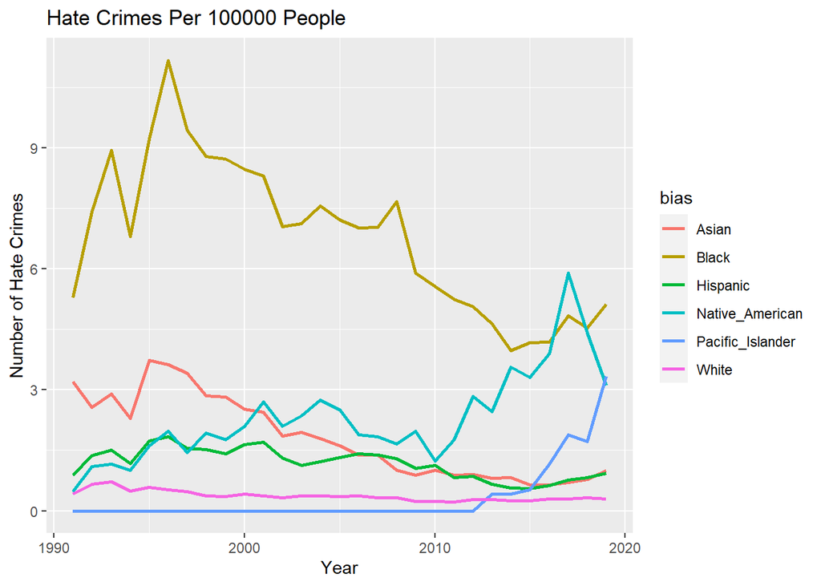

```r
Per_Capita_Race <- data.frame(year = c(1991:2019))
Per_Capita_Race$Asian <- round(100000*Race_Total$Asian/Race_Pop$Asian,digits = 2)
Per_Capita_Race$Black <- round(100000*Race_Total$Black/Race_Pop$Black, digits = 2)
Per_Capita_Race$Hispanic <- round(100000*Race_Total$Hispanic/Race_Pop$Hispanic, digits = 2)
Per_Capita_Race$Native_American <- round(100000*Race_Total$Native_American/Race_Pop$Native_American, digits = 2)
Per_Capita_Race$Pacific_Islander <- round(100000*Race_Total$Pacific_Islander/Race_Pop$Pacific_Islander, digits = 2)
Per_Capita_Race$White <- round(100000*Race_Total$White/Race_Pop$White, digits = 2)

Per_Capita_Race_stacked <- cbind(Per_Capita_Race[1],stack(Per_Capita_Race[2:7]))
colnames(Per_Capita_Race_stacked) <- c("year", "nHate_Crimes", "bias")

ggplot(data = Per_Capita_Race_stacked, mapping = aes(x = year, y = nHate_Crimes)) +
  geom_line(mapping = aes(color = bias), size = 1) +
  xlab("Year") +
  ylab("Number of Hate Crimes") +
  ggtitle("Hate Crimes Per 100000 People")
```

- Note: racial populations are estimates using census data
- When we look at hate crimes per capita, we see the majority being against the black population.
- In the previous graph notice that there weren’t many hate crimes against Native Americans or Pacific Islanders. However, the low populations of these particular races yields a different result when we look at hate crimes per capita.
- Obviously, there are a lot of anti-white hate crimes, but since the white population is the majority in the US, hate crimes against White people are relatively small.
- 2018 is the last year the Cleveland baseball team used the name “Indians”, and Trump reversed veto in 2017 of the controversial Keystone XL pipeline which was to go through native land.
- 1992 LA race riots coming from the beating of Rodney King by the LA police department.